# cctbxPyMOLexamples

The cell below imports the cmd class of the pymol module and the Image method from Ipython. It also uses the cmd.do() method to load the pymolshortcuts.py script, which is found [here](https://github.com/MooersLab/pymolshortcuts/blob/master/pymolshortcuts.py).

```python
from pymol import cmd
from IPython.display import Image

PATH="/Users/blaine/"

cmd.do('run /Users/blaine/Scripts/\
PyMOLScripts/pymolshortcuts.py');
```

[output not shown]

[output cut: 298 more lines]

[output not shown]

The three horizonal dots above are the folded background information that is printed below the cell when the pymolshortcuts.py script is run.

The RNA below has PDB id 3nd3. It has a run of eight contiguous Us. It is from the RNA editing system in trypanosomes (Mooers and Singh 2012). The **U8** shortcut retrieves the coordinates from the Protein Data Banks, generates the second strand via crystallographic symmtery, and aligns the model along the y-axis. The **AOD** shortcut generates the ambient occlusion effect with black carbon atoms.

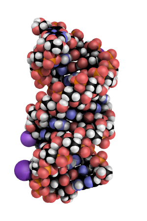

```python
cmd.do("rein;bg_color white;U8;")
cmd.do("hide nonbonded;AOD;")
cmd.png("3nd3.png",
        width=300,
        height=450,
        dpi=600)
Image(filename = PATH + "3nd3.png",
      width=300,
      height=450,
      unconfined=True)
```

The function below depends on the `sys` module which was imported with the running of the `shortcutspymol.py` script above. This demonstrates that PyMOL and CCTBX are sharing the same module.

```python
from cctbx import sgtbx

def get_symm(sg):
  """Code from Robert Campbell's list_symm.py script
  http://pldserver1.biochem.queensu.ca/~rlc/work/pymol/list_symm.py
  Copyright (c) 2004 Robert L. Campbell
  Modified by Mooers 1/6/2020 to run with Python3.
  """
  try:
    space_group_info = sgtbx.space_group_info(symbol=sg)
  except RuntimeError as err:
    print(err)
    sys.exit(1)

  space_group_info.show_summary()
  print(len(space_group_info.group()), space_group_info.group().n_smx())
  # print space_group symmetry information as x,y,z and as matrix row by row
  i = 1
  for smx in space_group_info.group():
    tlist = []
    rlist = []
    r, t = smx.r(), smx.t()
    for j in range(len(r.num())):
      rlist.append(float(r.num()[j]))
    for j in range(len(t.num())):
      tlist.append(t.num()[j]/24.)

    print("%3d %-24s %-50s %-20s" % (i, str(smx), str(rlist), str(tlist)))
    i += 1
```

The above RNA crystallized in space group H32 or 155.

```python
print(get_symm(155))
```

```
Space group: R 3 2 :H (No. 155)
18 6
  1 x,y,z                    [1.0, 0.0, 0.0, 0.0, 1.0, 0.0, 0.0, 0.0, 1.0]      [0.0, 0.0, 0.0]
  2 -y,x-y,z                 [0.0, -1.0, 0.0, 1.0, -1.0, 0.0, 0.0, 0.0, 1.0]    [0.0, 0.0, 0.0]
  3 -x+y,-x,z                [-1.0, 1.0, 0.0, -1.0, 0.0, 0.0, 0.0, 0.0, 1.0]    [0.0, 0.0, 0.0]
  4 x-y,-y,-z                [1.0, -1.0, 0.0, 0.0, -1.0, 0.0, 0.0, 0.0, -1.0]   [0.0, 0.0, 0.0]
  5 -x,-x+y,-z               [-1.0, 0.0, 0.0, -1.0, 1.0, 0.0, 0.0, 0.0, -1.0]   [0.0, 0.0, 0.0]
  6 y,x,-z                   [0.0, 1.0, 0.0, 1.0, 0.0, 0.0, 0.0, 0.0, -1.0]     [0.0, 0.0, 0.0]
  7 x+1/3,y+2/3,z+2/3        [1.0, 0.0, 0.0, 0.0, 1.0, 0.0, 0.0, 0.0, 1.0]      [0.16666666666666666, 0.3333333333333333, 0.3333333333333333]
  8 -y+1/3,x-y+2/3,z+2/3     [0.0, -1.0, 0.0, 1.0, -1.0, 0.0, 0.0, 0.0, 1.0]    [0.16666666666666666, 0.3333333333333333, 0.3333333333333333]
  9 -x+y+1/3,-x+2/3,z+2/3    [-1.0, 1.0, 0.0, -1.0, 0.0, 0.0, 0.0, 0.0, 1.0]    [0.16666666666666666, 0.3333333333333333, 0.3333333333333333]
 10 x-y+1/3,-y+2/3,-z+2/3    [1.0, -1.0, 0.0, 0.0, -1.0, 0.0, 0.0, 0.0, -1.0]   [0.16666666666666666, 0.3333333333333333, 0.3333333333333333]
 11 -x+1/3,-x+y+2/3,-z+2/3   [-1.0, 0.0, 0.0, -1.0, 1.0, 0.0, 0.0, 0.0, -1.0]   [0.16666666666666666, 0.3333333333333333, 0.3333333333333333]
 12 y+1/3,x+2/3,-z+2/3       [0.0, 1.0, 0.0, 1.0, 0.0, 0.0, 0.0, 0.0, -1.0]     [0.16666666666666666, 0.3333333333333333, 0.3333333333333333]
 13 x+2/3,y+1/3,z+1/3        [1.0, 0.0, 0.0, 0.0, 1.0, 0.0, 0.0, 0.0, 1.0]      [0.3333333333333333, 0.16666666666666666, 0.16666666666666666]
 14 -y+2/3,x-y+1/3,z+1/3     [0.0, -1.0, 0.0, 1.0, -1.0, 0.0, 0.0, 0.0, 1.0]    [0.3333333333333333, 0.16666666666666666, 0.16666666666666666]
 15 -x+y+2/3,-x+1/3,z+1/3    [-1.0, 1.0, 0.0, -1.0, 0.0, 0.0, 0.0, 0.0, 1.0]    [0.3333333333333333, 0.16666666666666666, 0.16666666666666666]
 16 x-y+2/3,-y+1/3,-z+1/3    [1.0, -1.0, 0.0, 0.0, -1.0, 0.0, 0.0, 0.0, -1.0]   [0.3333333333333333, 0.16666666666666666, 0.16666666666666666]
 17 -x+2/3,-x+y+1/3,-z+1/3   [-1.0, 0.0, 0.0, -1.0, 1.0, 0.0, 0.0, 0.0, -1.0]   [0.3333333333333333, 0.16666666666666666, 0.16666666666666666]
 18 y+2/3,x+1/3,-z+1/3       [0.0, 1.0, 0.0, 1.0, 0.0, 0.0, 0.0, 0.0, -1.0]     [0.3333333333333333, 0.16666666666666666, 0.16666666666666666]
None
```

The model.pdb coordinates are found in the data folder on the github site. They were generated in the CCTBX tutorial.

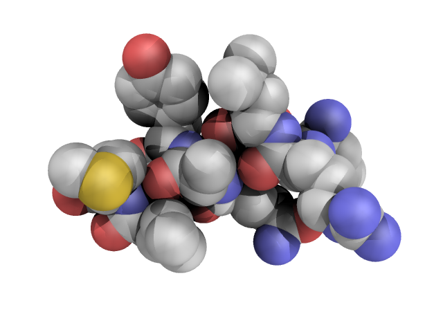

```python
cmd.do("rein;bg_color white;load model.pdb")
cmd.do("orient;hide nonbonded;AO;png modelAO.png")
Image(filename=PATH+"modelAO.png", width=500, height=500, unconfined=True)
```

The code below generates the grayscale version of the above figure.

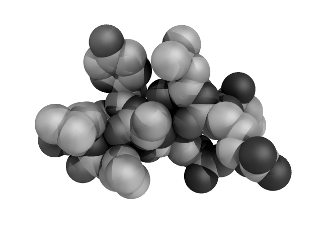

```python
cmd.do("rein;bg_color white;load model.pdb")
cmd.do("orient;hide nonbonded;AOBW;png modelAOBW.png")
Image(filename=PATH+"modelAObW.png", width=500, height=500, unconfined=True)
```

```python
The diffraction data for 3hz7 is found in the data folder on the github site.
```

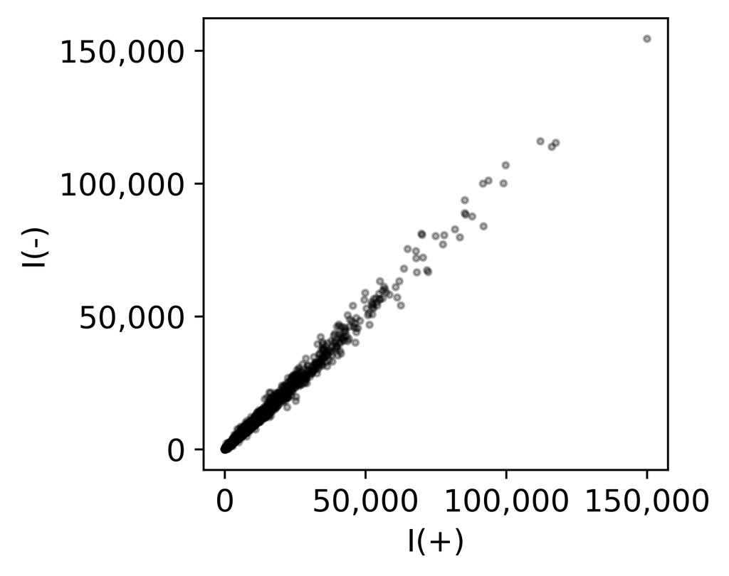

```python
%matplotlib inline
import matplotlib.pyplot as plt
import matplotlib as mpl
import matplotlib.ticker as ticker
from matplotlib.ticker import MultipleLocator #, FormatStrFormatter
from matplotlib.ticker import FuncFormatter
from iotbx.reflection_file_reader import any_reflection_file

# >>> change the mtz file name
hkl_file = any_reflection_file('3hz7.mtz')
miller_arrays = hkl_file.as_miller_arrays(merge_equivalents=False)
Iobs = miller_arrays[1]
i_plus, i_minus = Iobs.hemispheres_acentrics()
ipd = i_plus.data()
ip=list(ipd)
imd = i_minus.data()
im = list(imd)
len(im)

comma_fmt = FuncFormatter(lambda x, p: format(int(x), ','))

mpl.rcParams['savefig.dpi'] = 600
mpl.rcParams['figure.dpi'] = 600

# Set to width of a one column on a two-column page.
# May want to adjust settings for a slide.
fig, ax = plt.subplots(figsize=[3.25, 3.25])
ax.scatter(ip,im,c='k',alpha=0.3,s=5.5)
ax.set_xlabel(r'I(+)',fontsize=12)
ax.set_ylabel(r'I(-)',fontsize=12)
ax.xaxis.set_major_locator(MultipleLocator(50000.))
ax.yaxis.set_major_locator(MultipleLocator(50000.))
ax.get_xaxis().set_major_formatter(comma_fmt)
ax.get_yaxis().set_major_formatter(comma_fmt)

plt.xticks(fontsize=12)
plt.yticks(fontsize=12)
ax.grid(False)

# >>> change name of the figure file
plt.savefig('3hz7IpIm.pdf',bbox_inches='tight')
```

```python
help(ax.scatter)
```

[output not shown]

[output cut: 63 more lines]

[output not shown]

```python
from iotbx import mtz
mtz_obj = mtz.object(file_name="/Users/blaine/3hz7.mtz")
mtz_obj.show_summary()
```

```
Title: phenix.cif_as_mtz
Space group symbol from file: P43212
Space group number from file: 96
Space group from matrices: P 43 21 2 (No. 96)
Point group symbol from file: 422
Number of crystals: 2
Number of Miller indices: 6482
Resolution range: 25.5941 1.99683
History:
Crystal 1:
  Name: HKL_base
  Project: HKL_base
  Id: 0
  Unit cell: (46.046, 46.046, 82.811, 90, 90, 90)
  Number of datasets: 1
  Dataset 1:
    Name: HKL_base
    Id: 0
    Wavelength: 0
    Number of columns: 0
Crystal 2:
  Name: crystal_0
  Project: project
  Id: 2
  Unit cell: (46.046, 46.046, 82.811, 90, 90, 90)
  Number of datasets: 1
  Dataset 1:
    Name: dataset
    Id: 1
    Wavelength: 0.97976
    Number of columns: 11
    label   #valid  %valid    min       max type
    H         6482 100.00%   0.00     22.00 H: index h,k,l
    K         6482 100.00%   0.00     16.00 H: index h,k,l
    L         6482 100.00%   0.00     41.00 H: index h,k,l
    F(+)      6448  99.48%   0.00    476.80 G: F(+) or F(-)
    SIGF(+)   6448  99.48%   0.00     10.19 L: standard deviation
    F(-)      5005  77.21%   0.00    393.03 G: F(+) or F(-)
    SIGF(-)   5005  77.21%   0.00      8.88 L: standard deviation
    I(+)      6448  99.48% -76.20 227334.00 K: I(+) or I(-)
    SIGI(+)   6448  99.48%   4.00   4014.00 M: standard deviation
    I(-)      5005  77.21% -98.90 154474.00 K: I(+) or I(-)
    SIGI(-)   5005  77.21%  10.20   2081.00 M: standard deviation
```

```
<iotbx_mtz_ext.object at 0x7fce70c73370>
```

```python
Below are some examples of retrieving from the RCSB atomic coordinates, diffraction data, sequence data, and unit cell dimensions by using CCTBX.
```

```python
from iotbx.pdb.fetch import get_pdb
import sys
get_pdb(id="3nd4",data_type="xray", mirror="rcsb", format="cif", log=sys.stdout)
```

```
Structure factors saved to /Users/blaine/3nd4-sf.cif
```

```
'/Users/blaine/3nd4-sf.cif'
```

```python
from iotbx.pdb.fetch import get_pdb
import sys
get_pdb(id="3nd4",data_type="pdb", mirror="rcsb", format="cif", log=sys.stdout)
```

```
Model saved to /Users/blaine/3nd4.cif
```

```
'/Users/blaine/3nd4.cif'
```

```python
from iotbx.pdb.fetch import get_pdb
import sys
get_pdb(id="3nd4",data_type="pdb", mirror="rcsb", format="pdb", log=sys.stdout)
```

```
Model saved to /Users/blaine/3nd4.pdb
```

```
'/Users/blaine/3nd4.pdb'
```

```python
from iotbx.pdb.fetch import get_pdb
import sys
get_pdb(id="3nd4",data_type="fasta", mirror="rcsb", format="pdb", log=sys.stdout)
```

```
Sequence saved to /Users/blaine/3nd4.fa
```

```
'/Users/blaine/3nd4.fa'
```

```python
import iotbx
help(iotbx.pdb.crystal_symmetry_from_pdb)
```

```
Help on module iotbx.pdb.crystal_symmetry_from_pdb in iotbx.pdb:

NAME
    iotbx.pdb.crystal_symmetry_from_pdb

FUNCTIONS
    extract_from(file_name=None, file=None, monitor_initial=None)

DATA
    absolute_import = _Feature((2, 5, 0, 'alpha', 1), (3, 0, 0, 'alpha', 0...
    division = _Feature((2, 2, 0, 'alpha', 2), (3, 0, 0, 'alpha', 0), 1310...
    print_function = _Feature((2, 6, 0, 'alpha', 2), (3, 0, 0, 'alpha', 0)...

FILE
    /opt/anaconda/envs/p242c38/lib/python3.8/site-packages/iotbx/pdb/crystal_symmetry_from_pdb.py
```

```python
iotbx.pdb.crystal_symmetry_from_pdb.extract_from("3nd4.pdb")
```

```
crystal.symmetry(
    unit_cell=(41.094, 41.094, 123.69, 90, 90, 120),
    space_group_symbol="R 3 2 :H"
  )
```

```python
ls /opt/anaconda/envs/p242c38/lib/python3.8/site-packages/cctbx/sgtbx
```

```
__init__.py			   rotation_matrices.h
__pycache__/			   row_echelon_solve.h
basic.h				   rt_mx.h
boost_python/			   rt_mx_hash.h
bravais_types.py		   search_symmetry.h
brick.h				   select_generators.h
change_of_basis_op.h		   seminvariant.h
cosets.py			   show_cosets.py
direct_space_asu/		   site_constraints.h
find_affine.h			   site_symmetry.h
group_codes.h			   site_symmetry_table.h
harker.py			   smith_normal_form.h
lattice_symmetry.h		   space_group.h
lattice_symmetry.py		   space_group_hash.h
lattice_tr.h			   space_group_type.h
literal_description.py		   sub_lattice_tools.py
miller_ops.h			   subgroups.py
operator_from_axis_direction.h	   sym_equiv_sites.h
parse_string.h			   symbol_confidence.py
phase_info.h			   symbols.h
plane_groups.py			   sys_abs_equiv.h
pointgroup_tools.py		   sys_abs_equiv.py
rational_matrices_point_groups.py  tensor_rank_2.h
reciprocal_space_asu.h		   tensors.h
reciprocal_space_reference_asu.h   tr_group.h
reference_settings.h		   tr_group_hash.h
reticular_pg_tools.py		   tr_vec.h
reticular_twin_laws.py		   tr_vec_hash.h
rot_mx.h			   utils.h
rot_mx_hash.h			   wyckoff.h
rot_mx_info.h
```

```python
from mmtbx.maps.utils import create_map_from_pdb_and_mtz
"""The phenix.maps commandline tool is the recommended approach."""
id="3nd4"
create_map_from_pdb_and_mtz(
          pdb_file="%s.pdb" % id,
          mtz_file="%s.mtz" % id,
          output_file="%s_maps.mtz" % id,
          fill=False,
          out=None,
          llg_map=False,
          remove_unknown_scatterering_type=True,
          assume_pdb_data=False)
```

Demonstration of how to run conda inside of a Jupyter Notebook. Here, the available envs are being listed. You can also install new Python packages with conda.

```python
!conda env list
```

```
# conda environments:
#
                         /Applications/PyMOL.app/Contents
                         /Users/blaine/.julia/conda/3
                         /Users/blaine/software/cctbxConda/conda_base
                         /Users/blaine/software/pymolBScctbx/conda_base
base                     /opt/anaconda
amber20                  /opt/anaconda/envs/amber20
anazeus                  /opt/anaconda/envs/anazeus
bayesian-modelling-tutorial     /opt/anaconda/envs/bayesian-modelling-tutorial
biobb_MDsetup_tutorial     /opt/anaconda/envs/biobb_MDsetup_tutorial
cctb37                   /opt/anaconda/envs/cctb37
cctbx37conda             /opt/anaconda/envs/cctbx37conda
chemprop38               /opt/anaconda/envs/chemprop38
countNB                  /opt/anaconda/envs/countNB
cpp                      /opt/anaconda/envs/cpp
dask-tutorial            /opt/anaconda/envs/dask-tutorial
dc23py36                 /opt/anaconda/envs/dc23py36
dc23py37                 /opt/anaconda/envs/dc23py37
diffypy38                /opt/anaconda/envs/diffypy38
doepipeline              /opt/anaconda/envs/doepipeline
env1                     /opt/anaconda/envs/env1
gpflowopt36              /opt/anaconda/envs/gpflowopt36
ipykernel_py2            /opt/anaconda/envs/ipykernel_py2
jL37                     /opt/anaconda/envs/jL37
jL38                     /opt/anaconda/envs/jL38
jnb5710                  /opt/anaconda/envs/jnb5710
labx                     /opt/anaconda/envs/labx
masif27                  /opt/anaconda/envs/masif27
numpyro37                /opt/anaconda/envs/numpyro37
oepython                 /opt/anaconda/envs/oepython
p242c38                  /opt/anaconda/envs/p242c38
pc38                  *  /opt/anaconda/envs/pc38
pnab                     /opt/anaconda/envs/pnab
pymc3_resources          /opt/anaconda/envs/pymc3_resources
pymol37                  /opt/anaconda/envs/pymol37
pymolcctbx               /opt/anaconda/envs/pymolcctbx
pyropy37                 /opt/anaconda/envs/pyropy37
tf2py37                  /opt/anaconda/envs/tf2py37
xarray                   /opt/anaconda/envs/xarray
```